# HW 3a: Penguin t-tests and correlation

MSCI 599

12/30/2020

#### Unit 3: Penguins

#### Homework # 3a t-tests and correlations

#### Skill practice: data exploration, basic statistical diagnostics, t-tests, correlations

Use the `palmerpenguins` dataset in R to answer the following questions:

Find literature values of Adelie and Chinstrap body mass. You can use the Encyclopedia of Life https://eol.org/ or find values elsewhere in the literature.

(I feel like this got out of hand, so I’m copy/pasting the questions and answers up here in case that makes grading easier. I’m also leaving them next to the corresponding code so you can see what I was doing.)

1. Are our observations of Adelie body mass significantly different from the literature?
- The Palmer station observations of Adelie body mass are significantly different from the literature (p-value < 2.2e-16)
- The Palmer station mean body weight is 3700.7 g, and the accepted value for adult Adelie penguins from Encyclopedia of life is 4700 g.
- This is based on a Wilcoxon signed rank test with continuity correction
- This assumes no significant outliers and that the data are not normally distributed (based on Shapiro-Wilk test for normality)
2. Are our observations of Chinstrap body mass significantly different from the literature?
- The Palmer station observations of Chinstrap penguin body mass are not significantly different from the literature (p-value = 0.2263)
- The Palmer station mean body weight is 3733.1 g, and the accepted value for adult Chinstrap penguins from Moreno and Sanz (1996) is 3790 g.
- This is based on a one-sample t-test
- This assumes that the data are normally distributed (based on Shapiro-Wilk test for normality)
3. Are Adelie and Chinstrap body masses significantly different from each other?
- Adelie and chinstrap penguin body mass are not significantly different from each other (p=0.5879)
- Welch’s t-test was used. This assumes roughly normal distribution, no significant outliers, and independence of observations.
4. What is the correlation between flipper length and body mass with all penguin species combined into a single dataset?
- There is a strong positive correlation between flipper length and body mass for all penguins
- Pearson’s r = 0.8712
5. What is the correlation between flipper length and body mass for each of the 3 species separately? In which species are these 2 biological metrics least correlated? Most correlated?
- The correlation between flipper length and body mass for Adelie penguins is 0.4682. This was the species in which flipper length and body mass were least correlated.
- The correlation between flipper length and body mass for Chinstrap penguins is 0.6416
- The correlation between flipper length and body mass for Gentoo penguins is 0.7027. This was the species in which flipper length and body mass were most correlated.
1. Are our observations of Adelie body mass significantly different from the literature?

```r
library(palmerpenguins)
library(tidyverse)
library(rstatix)
library(GGally)
## per EoL: Mean Adult Adelie body mass = 4700 g (https://eol.org/data/R57-PK132020496)
Adelie_mass_EoL=4700

Adelie= penguins %>%
  filter(species=="Adelie")

Adelie_mass_Palmer= mean(Adelie$body_mass_g, na.rm = TRUE)
## Mean body mass from Palmer = 3700.7 g

summary(Adelie$body_mass_g)
```

```
##    Min. 1st Qu.  Median    Mean 3rd Qu.    Max.    NA's
##    2850    3350    3700    3701    4000    4775       1
```

```r
sd(Adelie$body_mass_g, na.rm = TRUE)
```

```
## [1] 458.5661
## standard deviation from Palmer = 458.6 g
```

```r
Adelie %>%
  identify_outliers(body_mass_g) #no outliers
```

```
##  [1] species           island            bill_length_mm    bill_depth_mm
##  [5] flipper_length_mm body_mass_g       sex               year
##  [9] is.outlier        is.extreme
## <0 rows> (or 0-length row.names)
```

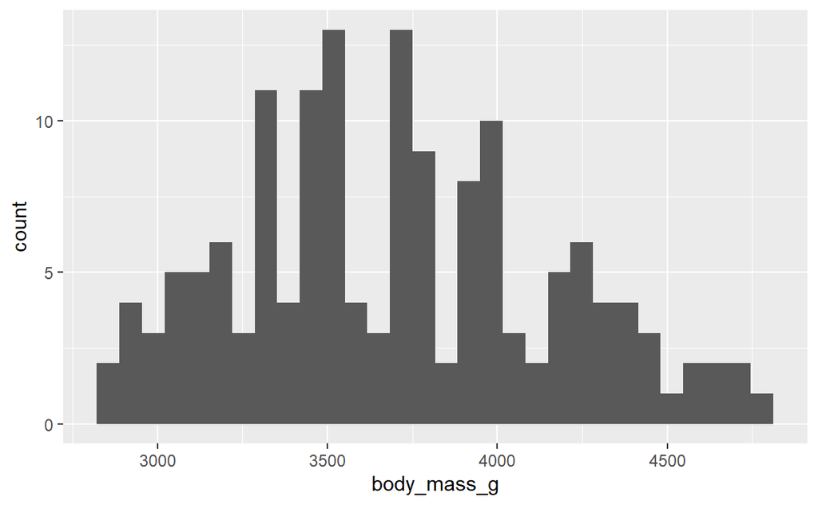

```r
ggplot(data=Adelie) +
  geom_histogram(aes(x=body_mass_g))
## `stat_bin()` using `bins = 30`. Pick better value with `binwidth`.
## Warning: Removed 1 rows containing non-finite values (stat_bin).
```

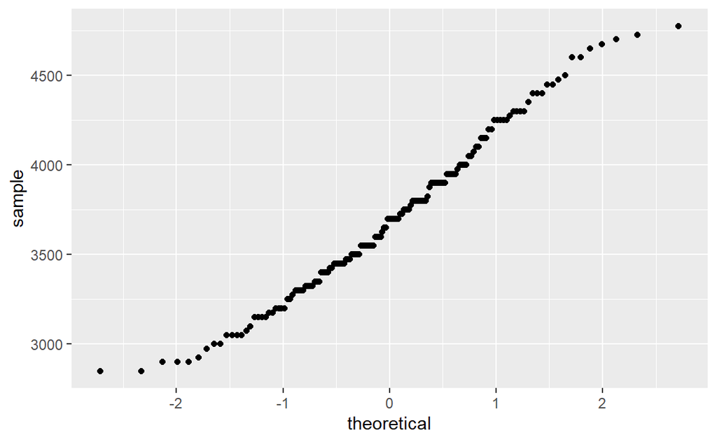

```r
ggplot(Adelie)+
  stat_qq(aes(sample=body_mass_g))
```

```r
shapiro.test(Adelie$body_mass_g)
```

```
##
##  Shapiro-Wilk normality test
##
## data:  Adelie$body_mass_g
## W = 0.98071, p-value = 0.0324
```

```r
# p-value= 0.0324, meaning not normally distributed

wilcox.test(Adelie$body_mass_g, mu= Adelie_mass_EoL, alternative = "two.sided")
```

```
##
##  Wilcoxon signed rank test with continuity correction
##
## data:  Adelie$body_mass_g
## V = 5.5, p-value < 2.2e-16
## alternative hypothesis: true location is not equal to 4700
```

```r
#  p-value < 2.2e-16
```

- The Palmer station observations of Adelie body mass are significantly different from the literature (p-value < 2.2e-16)
- The Palmer station mean body weight is 3700.7 g, and the accepted value for adult Adelie penguins from Encyclopedia of life is 4700 g.
- This is based on a Wilcoxon signed rank test with continuity correction
- This assumes no significant outliers and that the data are not normally distributed (based on Shapiro-Wilk test for normality)
2. Are our observations of Chinstrap body mass significantly different from the literature?

```r
## Per Moreno and Sanz (1996) (https://www.jstor.org/stable/30164217?seq=1), mean body mass of chinstrap penguins = 3790 g

Chinstrap_mass_lit= 3790

Chinstrap= penguins %>%
  filter(species=="Chinstrap")

Chinstrap_mass_Palmer = mean(Chinstrap$body_mass_g, na.rm = TRUE)
# Mean body mass from Palmer = 3733.1 g

summary(Chinstrap$body_mass_g)
```

```
##    Min. 1st Qu.  Median    Mean 3rd Qu.    Max.
##    2700    3488    3700    3733    3950    4800
```

```r
sd(Chinstrap$body_mass_g, na.rm = TRUE)
```

```
## [1] 384.3351
```

```r
# Standard deviation of Chinstrap body mass = 384.3 g

Chinstrap %>%
  identify_outliers(body_mass_g) # contains 2 outliers: 4800 g male and 2700 g female
```

```
## # A tibble: 2 x 10
##   species island bill_length_mm bill_depth_mm flipper_length_~ body_mass_g sex
##   <fct>   <fct>           <dbl>         <dbl>            <int>       <int> <fct>
## 1 Chinst~ Dream            52            20.7              210        4800 male
## 2 Chinst~ Dream            46.9          16.6              192        2700 fema~
## # ... with 3 more variables: year <int>, is.outlier <lgl>, is.extreme <lgl>
```

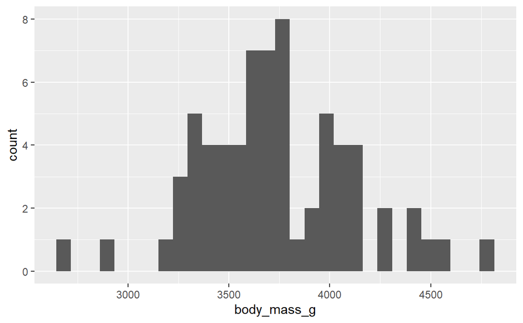

```r
ggplot(data=Chinstrap) +
  geom_histogram(aes(x=body_mass_g))
## `stat_bin()` using `bins = 30`. Pick better value with `binwidth`.
```

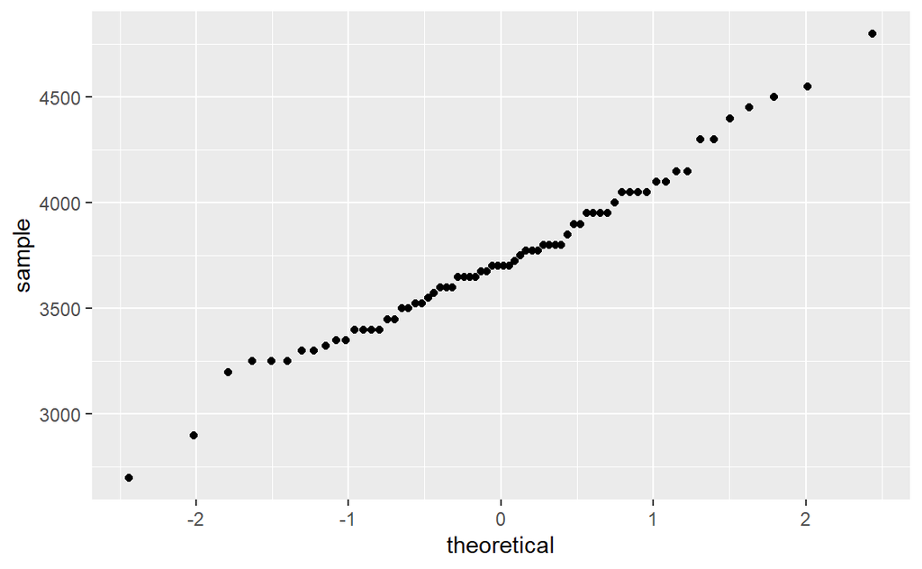

```r
ggplot(Chinstrap)+
  stat_qq(aes(sample=body_mass_g))
```

```r
shapiro.test(Chinstrap$body_mass_g)
```

```
##
##  Shapiro-Wilk normality test
##
## data:  Chinstrap$body_mass_g
## W = 0.98449, p-value = 0.5605
```

```r
# p-value = 0.5605, meaning data are normally distributed

t.test(Chinstrap$body_mass_g, mu= Chinstrap_mass_lit)
```

```
##
##  One Sample t-test
##
## data:  Chinstrap$body_mass_g
## t = -1.2211, df = 67, p-value = 0.2263
## alternative hypothesis: true mean is not equal to 3790
## 95 percent confidence interval:
##  3640.059 3826.117
## sample estimates:
## mean of x
##  3733.088
```

```r
# p-value = 0.2263, meaning the mean mass from Palmer is not statistically significantly different from the accepted value
```

- The Palmer station observations of Chinstrap penguin body mass are not significantly different from the literature (p-value = 0.2263)
- The Palmer station mean body weight is 3733.1 g, and the accepted value for adult Chinstrap penguins from Moreno and Sanz (1996) is 3790 g.
- This is based on a one-sample t-test
- This assumes that the data are normally distributed (based on Shapiro-Wilk test for normality)
3. Are Adelie and Chinstrap body masses significantly different from each other?

```r
Adelie_Chinstrap_mass = penguins %>%
  filter(species %in% c("Adelie", "Chinstrap"),
         !is.na(body_mass_g)) %>%
  select(species, body_mass_g) %>%
  droplevels()

Adelie_Chinstrap_mass %>%
  group_by(species) %>%
  summarize(mean=mean(body_mass_g), sd=sd(body_mass_g))
```

```
## # A tibble: 2 x 3
##   species    mean    sd
## * <fct>     <dbl> <dbl>
## 1 Adelie    3701.  459.
## 2 Chinstrap 3733.  384.
```

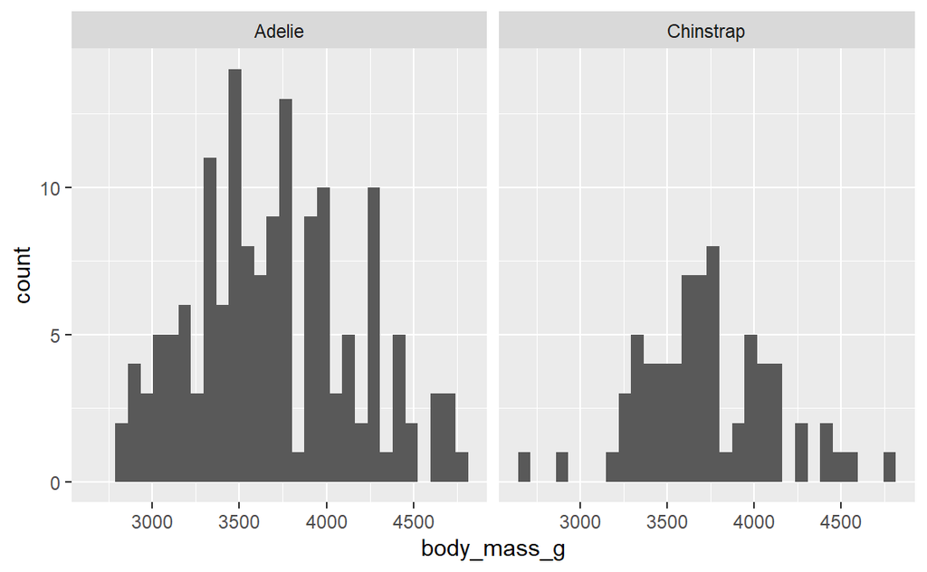

```r
ggplot(aes(x=body_mass_g), data= Adelie_Chinstrap_mass)+
  geom_histogram()+
  facet_wrap(~species)
## `stat_bin()` using `bins = 30`. Pick better value with `binwidth`.
```

```r
Adelie_Chinstrap_mass %>%
  group_by(species) %>%
  identify_outliers(body_mass_g)
```

```
## # A tibble: 2 x 4
##   species   body_mass_g is.outlier is.extreme
##   <fct>           <int> <lgl>      <lgl>
## 1 Chinstrap        4800 TRUE       FALSE
## 2 Chinstrap        2700 TRUE       FALSE
```

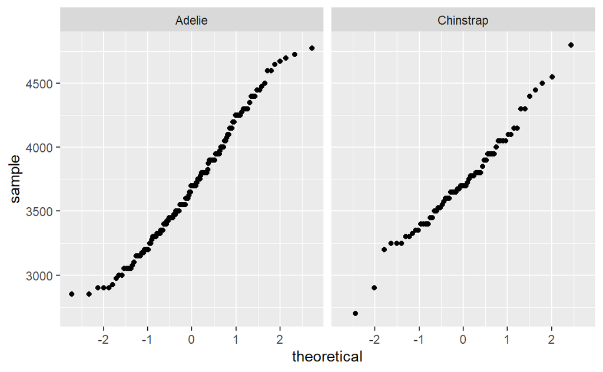

```r
# There are 2 outliers in Chinstrap: 1 penguin at 4800 g and 1 penguin at 2700 g

ggplot(Adelie_Chinstrap_mass) +
  stat_qq(aes(sample=body_mass_g))+
  facet_wrap(~species)
```

```r
shapiro.test(Adelie_Chinstrap_mass$body_mass_g)
```

```
##
##  Shapiro-Wilk normality test
##
## data:  Adelie_Chinstrap_mass$body_mass_g
## W = 0.98893, p-value = 0.08978
```

```r
# p-value = 0.08978 so data are mostly normally distributed

Adelie_Chinstrap_mass %>% levene_test(body_mass_g ~ species)
```

```
## # A tibble: 1 x 4
##     df1   df2 statistic      p
##   <int> <int>     <dbl>  <dbl>
## 1     1   217      4.82 0.0291
```

```r
# p-value = 0.029, meaning the variances are not equal

t.test(Adelie_Chinstrap_mass$body_mass_g ~ Adelie_Chinstrap_mass$species)
```

```
##
##  Welch Two Sample t-test
##
## data:  Adelie_Chinstrap_mass$body_mass_g by Adelie_Chinstrap_mass$species
## t = -0.54309, df = 152.45, p-value = 0.5879
## alternative hypothesis: true difference in means is not equal to 0
## 95 percent confidence interval:
##  -150.38481   85.53284
## sample estimates:
##    mean in group Adelie mean in group Chinstrap
##                3700.662                3733.088
```

```r
# p-value = 0.5879, so we fail to reject the null hypothesis that there's no significant difference in mean body mass for Adelie and Chinstrap penguins

Adelie_Chinstrap_mass %>% cohens_d(body_mass_g ~ species)
```

```
## # A tibble: 1 x 7
##   .y.         group1 group2    effsize    n1    n2 magnitude
## * <chr>       <chr>  <chr>       <dbl> <int> <int> <ord>
## 1 body_mass_g Adelie Chinstrap -0.0766   151    68 negligible
```

```r
# negligible effect size
```

- Adelie and chinstrap penguin body mass are not significantly different from each other (p=0.5879)
- Welch’s t-test was used. This assumes roughly normal distribution, no significant outliers, and independence of observations.
4. What is the correlation between flipper length and body mass with all penguin species combined into a single dataset?

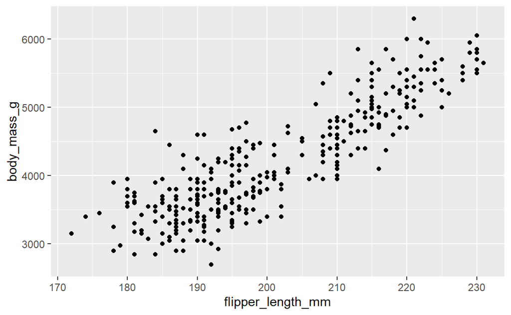

```r
ggplot()+
  geom_point(aes(x=flipper_length_mm, y=body_mass_g), data=penguins)
```

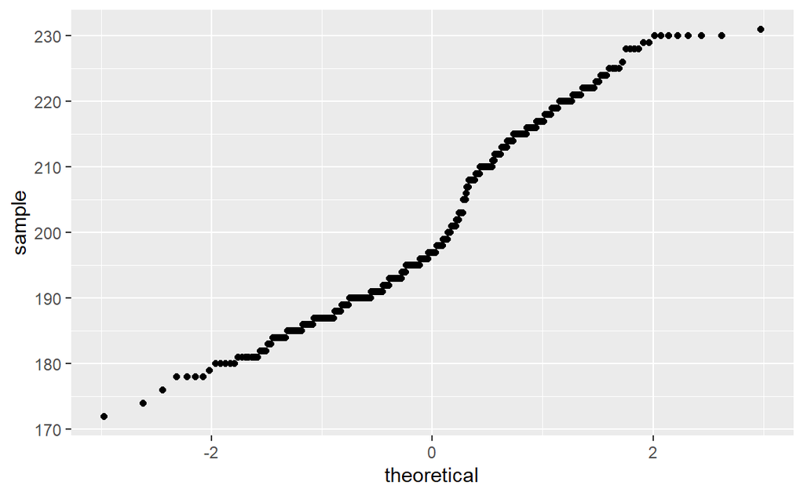

```r
ggplot(penguins)+
  stat_qq(aes(sample=flipper_length_mm))
```

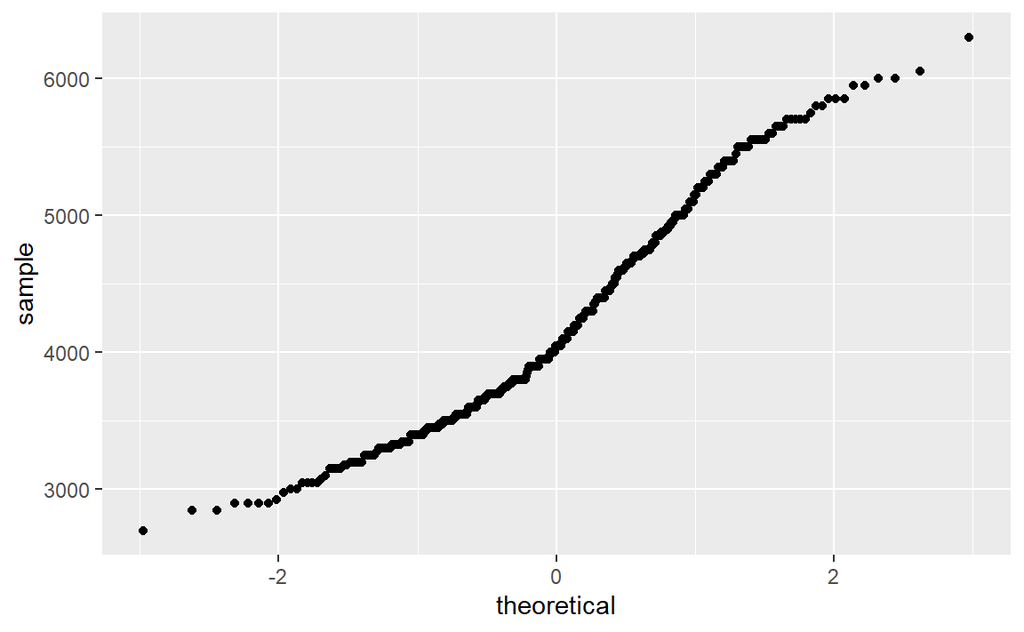

```r
ggplot(penguins) +
  stat_qq(aes(sample=body_mass_g))
```